# Graphic Exploration

Leslie O’Bray

May 1, 2018

## Exploratory Analysis: Mirrored bar plots

### External Review Step: Relationship of the different grades on IsApproved

#### OverallGrade and IsApproved

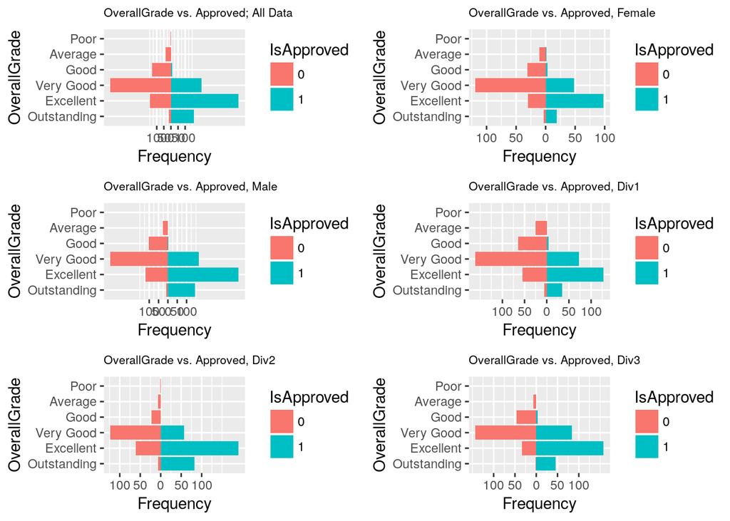

#### ApplicantTrack and IsApproved

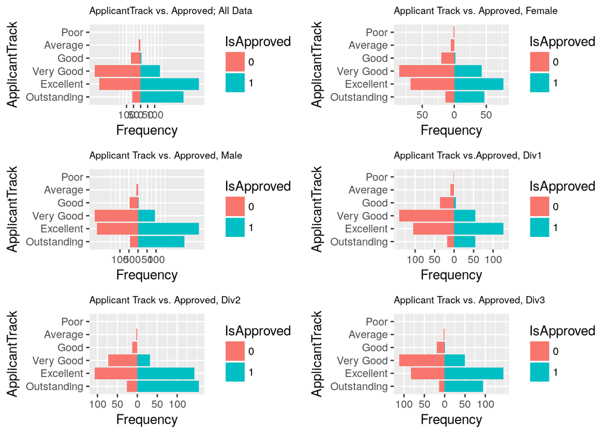

#### ScientificProposal and IsApproved

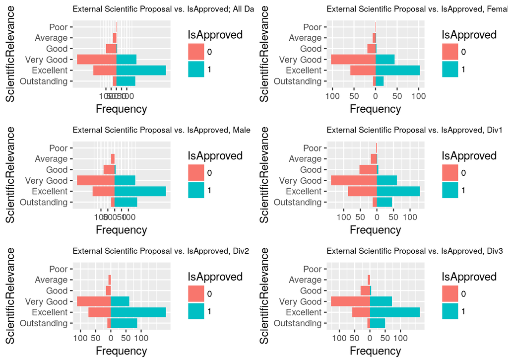

#### Suitability and IsApproved

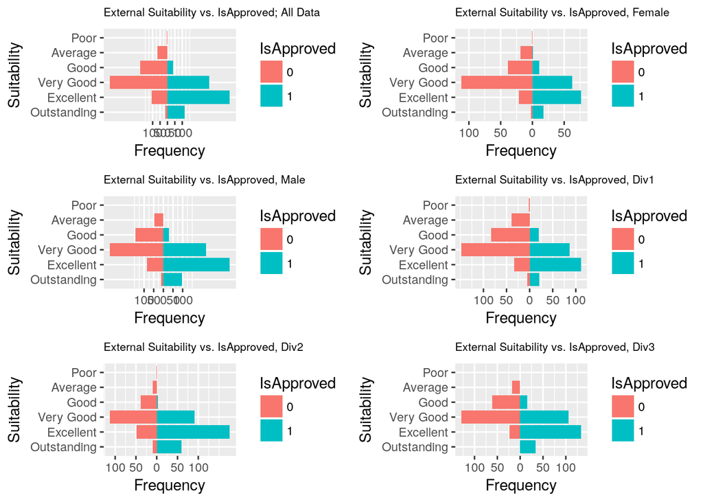

### Internal Review Step: Relationship of the different grades on IsApproved

#### Ranking and IsApproved

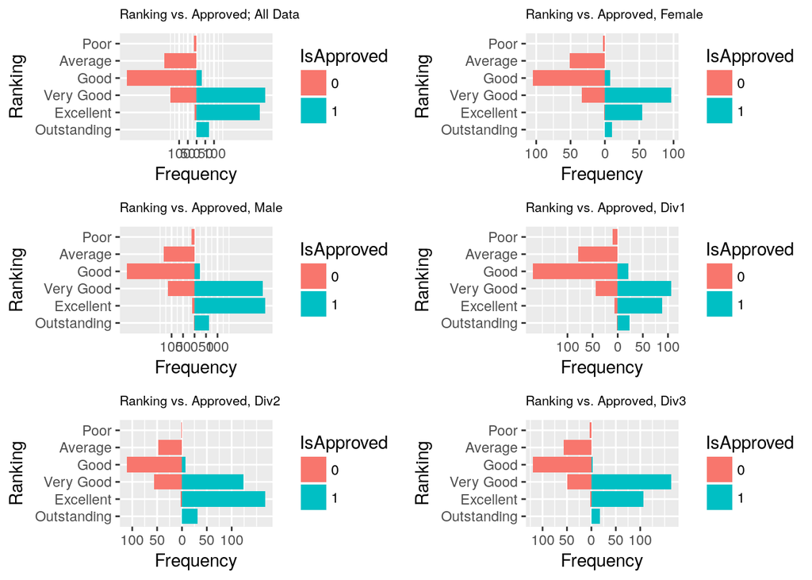

#### ApplicantTrack and IsApproved

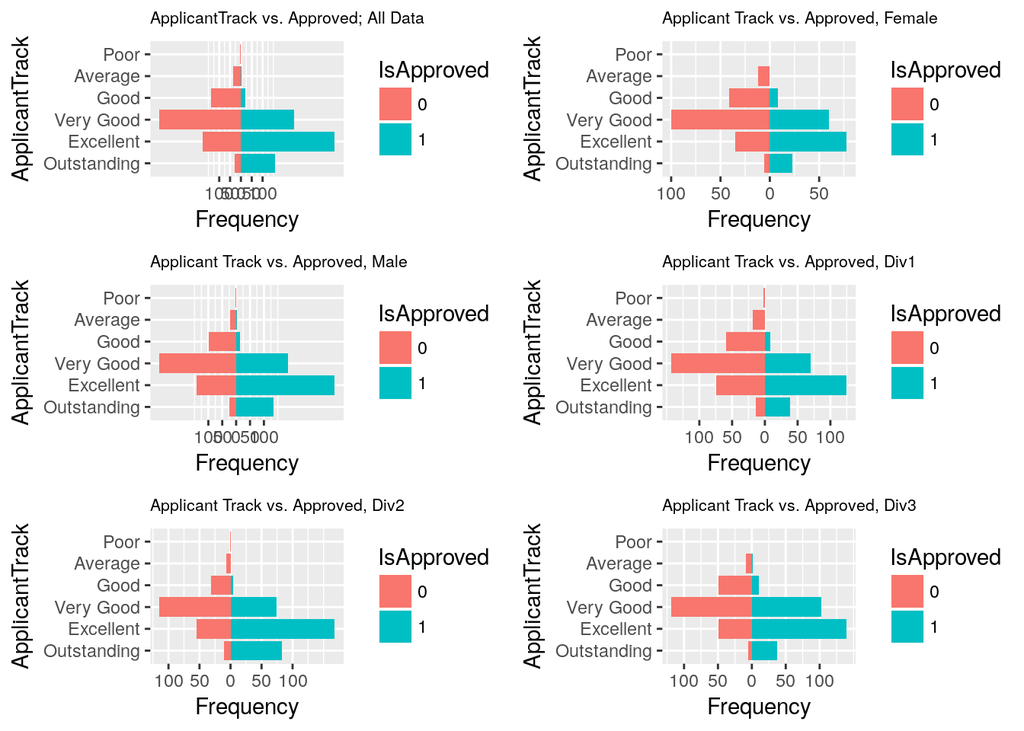

#### ScientificProposal and IsApproved

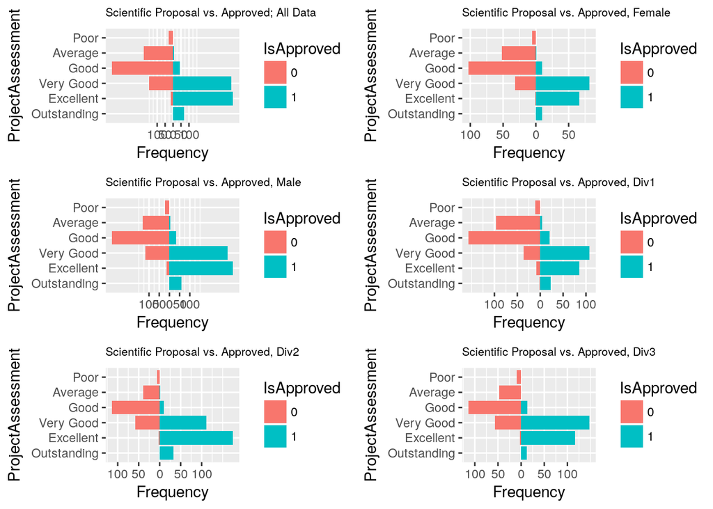

## Exploratory Analysis: Distribution tables

#### External Reviewers

|  | #Total |  | Gender m Result Rejected | Gender m Result Accepted | Gender | Gender f Result Rejected | Gender f Result Accepted |  | Division Div 1 Result Rejected | Division Div 1 Result Accepted | Division | Division Div 2 Result Rejected | Division Div 2 Result Accepted | Division | Division Div 3 Result Rejected | Division Div 3 Result Accepted |
| --- | --- | --- | --- | --- | --- | --- | --- | --- | --- | --- | --- | --- | --- | --- | --- | --- |
| Overall Reviewer grade |  |  |  |  |  |  |  |  |  |  |  |  |  |  |  |  |
| poor | 1 |  | 1 |  |  |  |  |  |  |  |  | 1 |  |  |  |  |
| average | 39 |  | 27 |  |  | 11 | 1 |  | 25 | 1 |  | 6 |  |  | 7 |  |
| good | 140 |  | 102 | 4 |  | 31 | 3 |  | 64 | 4 |  | 23 |  |  | 46 | 3 |
| very good | 641 |  | 308 | 166 |  | 119 | 48 |  | 161 | 73 |  | 123 | 57 |  | 143 | 84 |
| excellent | 626 |  | 120 | 378 |  | 30 | 98 |  | 55 | 128 |  | 61 | 190 |  | 34 | 158 |
| outstanding | 176 |  | 10 | 144 |  | 3 | 19 |  | 6 | 35 |  | 6 | 83 |  | 1 | 45 |
| #Total cases | 1623 |  | 568 | 692 |  | 194 | 169 |  | 311 | 241 |  | 220 | 330 |  | 231 | 290 |

|  | #Total |  | Gender m Result Rejected | Gender m Result Accepted | Gender | Gender f Result Rejected | Gender f Result Accepted |  | Division Div 1 Result Rejected | Division Div 1 Result Accepted | Division | Division Div 2 Result Rejected | Division Div 2 Result Accepted | Division | Division Div 3 Result Rejected | Division Div 3 Result Accepted |
| --- | --- | --- | --- | --- | --- | --- | --- | --- | --- | --- | --- | --- | --- | --- | --- | --- |
| Main Applicant Track |  |  |  |  |  |  |  |  |  |  |  |  |  |  |  |  |
| poor | 1 |  |  |  |  | 1 |  |  | 1 |  |  |  |  |  |  |  |
| average | 15 |  | 10 |  |  | 5 |  |  | 10 |  |  | 2 |  |  | 3 |  |
| good | 72 |  | 47 | 3 |  | 20 | 2 |  | 36 | 4 |  | 12 |  |  | 19 | 1 |
| very good | 463 |  | 240 | 94 |  | 86 | 43 |  | 141 | 55 |  | 73 | 32 |  | 112 | 50 |
| excellent | 710 |  | 227 | 338 |  | 68 | 77 |  | 105 | 127 |  | 107 | 143 |  | 83 | 145 |
| outstanding | 362 |  | 44 | 257 |  | 14 | 47 |  | 18 | 55 |  | 26 | 155 |  | 14 | 94 |
| #Total cases | 1623 |  | 568 | 692 |  | 194 | 169 |  | 311 | 241 |  | 220 | 330 |  | 231 | 290 |

|  | #Total |  | Gender m Result Rejected | Gender m Result Accepted | Gender | Gender f Result Rejected | Gender f Result Accepted |  | Division Div 1 Result Rejected | Division Div 1 Result Accepted | Division | Division Div 2 Result Rejected | Division Div 2 Result Accepted | Division | Division Div 3 Result Rejected | Division Div 3 Result Accepted |
| --- | --- | --- | --- | --- | --- | --- | --- | --- | --- | --- | --- | --- | --- | --- | --- | --- |
| ScientificRelevance |  |  |  |  |  |  |  |  |  |  |  |  |  |  |  |  |
| poor | 2 |  | 1 |  |  | 1 |  |  | 2 |  |  |  |  |  |  |  |
| average | 34 |  | 26 |  |  | 7 | 1 |  | 18 | 1 |  | 8 |  |  | 7 |  |
| good | 108 |  | 81 | 6 |  | 19 | 2 |  | 53 | 4 |  | 16 |  |  | 31 | 4 |
| very good | 569 |  | 273 | 149 |  | 103 | 44 |  | 138 | 60 |  | 111 | 61 |  | 127 | 72 |
| excellent | 695 |  | 161 | 373 |  | 58 | 103 |  | 87 | 130 |  | 74 | 182 |  | 58 | 164 |
| outstanding | 215 |  | 26 | 164 |  | 6 | 19 |  | 13 | 46 |  | 11 | 87 |  | 8 | 50 |
| #Total cases | 1623 |  | 568 | 692 |  | 194 | 169 |  | 311 | 241 |  | 220 | 330 |  | 231 | 290 |

|  | #Total |  | Gender m Result Rejected | Gender m Result Accepted | Gender | Gender f Result Rejected | Gender f Result Accepted |  | Division Div 1 Result Rejected | Division Div 1 Result Accepted | Division | Division Div 2 Result Rejected | Division Div 2 Result Accepted | Division | Division Div 3 Result Rejected | Division Div 3 Result Accepted |
| --- | --- | --- | --- | --- | --- | --- | --- | --- | --- | --- | --- | --- | --- | --- | --- | --- |
| Suitability |  |  |  |  |  |  |  |  |  |  |  |  |  |  |  |  |
| poor | 3 |  | 2 |  |  | 1 |  |  | 2 |  |  | 1 |  |  |  |  |
| average | 67 |  | 47 |  |  | 19 | 1 |  | 39 | 1 |  | 9 |  |  | 18 |  |
| good | 222 |  | 144 | 28 |  | 39 | 11 |  | 83 | 20 |  | 39 | 3 |  | 61 | 16 |
| very good | 674 |  | 278 | 221 |  | 112 | 63 |  | 148 | 87 |  | 113 | 91 |  | 129 | 106 |
| excellent | 527 |  | 84 | 345 |  | 21 | 77 |  | 34 | 112 |  | 48 | 176 |  | 23 | 134 |
| outstanding | 130 |  | 13 | 98 |  | 2 | 17 |  | 5 | 21 |  | 10 | 60 |  |  | 34 |
| #Total cases | 1623 |  | 568 | 692 |  | 194 | 169 |  | 311 | 241 |  | 220 | 330 |  | 231 | 290 |

#### Internal Reviewers

|  | #Total |  | Gender m Result Rejected | Gender m Result Accepted | Gender | Gender f Result Rejected | Gender f Result Accepted |  | Division Div 1 Result Rejected | Division Div 1 Result Accepted | Division | Division Div 2 Result Rejected | Division Div 2 Result Accepted | Division | Division Div 3 Result Rejected | Division Div 3 Result Accepted |
| --- | --- | --- | --- | --- | --- | --- | --- | --- | --- | --- | --- | --- | --- | --- | --- | --- |
| Overall Comparative Ranking |  |  |  |  |  |  |  |  |  |  |  |  |  |  |  |  |
| D | 15 |  | 12 |  |  | 3 |  |  | 10 |  |  | 2 |  |  | 3 |  |
| C | 184 |  | 133 |  |  | 51 |  |  | 79 |  |  | 48 |  |  | 57 |  |
| BC | 431 |  | 295 | 23 |  | 105 | 8 |  | 169 | 21 |  | 111 | 7 |  | 120 | 3 |
| B | 544 |  | 115 | 298 |  | 34 | 97 |  | 44 | 107 |  | 56 | 124 |  | 49 | 164 |
| AB | 375 |  | 11 | 309 |  | 1 | 54 |  | 7 | 89 |  | 3 | 168 |  | 2 | 106 |
| A | 74 |  | 2 | 62 |  |  | 10 |  | 2 | 24 |  |  | 31 |  |  | 17 |
| #Total cases | 1623 |  | 568 | 692 |  | 194 | 169 |  | 311 | 241 |  | 220 | 330 |  | 231 | 290 |

|  | #Total |  | Gender m Result Rejected | Gender m Result Accepted | Gender | Gender f Result Rejected | Gender f Result Accepted |  | Division Div 1 Result Rejected | Division Div 1 Result Accepted | Division | Division Div 2 Result Rejected | Division Div 2 Result Accepted | Division | Division Div 3 Result Rejected | Division Div 3 Result Accepted |
| --- | --- | --- | --- | --- | --- | --- | --- | --- | --- | --- | --- | --- | --- | --- | --- | --- |
| Main Applicant Track |  |  |  |  |  |  |  |  |  |  |  |  |  |  |  |  |
| poor | 3 |  | 3 |  |  |  |  |  | 2 |  |  | 1 |  |  |  |  |
| average | 37 |  | 23 | 2 |  | 12 |  |  | 19 |  |  | 7 | 1 |  | 9 | 1 |
| good | 161 |  | 98 | 14 |  | 41 | 8 |  | 59 | 8 |  | 31 | 4 |  | 49 | 10 |
| very good | 623 |  | 277 | 186 |  | 100 | 60 |  | 143 | 70 |  | 115 | 74 |  | 119 | 102 |
| excellent | 611 |  | 143 | 355 |  | 35 | 78 |  | 74 | 125 |  | 55 | 168 |  | 49 | 140 |
| outstanding | 188 |  | 24 | 135 |  | 6 | 23 |  | 14 | 38 |  | 11 | 83 |  | 5 | 37 |
| #Total cases | 1623 |  | 568 | 692 |  | 194 | 169 |  | 311 | 241 |  | 220 | 330 |  | 231 | 290 |

|  | #Total |  | Gender m Result Rejected | Gender m Result Accepted | Gender | Gender f Result Rejected | Gender f Result Accepted |  | Division Div 1 Result Rejected | Division Div 1 Result Accepted | Division | Division Div 2 Result Rejected | Division Div 2 Result Accepted | Division | Division Div 3 Result Rejected | Division Div 3 Result Accepted |
| --- | --- | --- | --- | --- | --- | --- | --- | --- | --- | --- | --- | --- | --- | --- | --- | --- |
| Project Assessment |  |  |  |  |  |  |  |  |  |  |  |  |  |  |  |  |
| poor | 27 |  | 21 |  |  | 6 |  |  | 11 |  |  | 6 |  |  | 10 |  |
| average | 188 |  | 131 | 4 |  | 52 | 1 |  | 97 | 4 |  | 39 | 1 |  | 47 |  |
| good | 428 |  | 282 | 33 |  | 103 | 10 |  | 157 | 20 |  | 114 | 10 |  | 114 | 13 |
| very good | 518 |  | 119 | 285 |  | 32 | 82 |  | 36 | 108 |  | 58 | 111 |  | 57 | 148 |
| excellent | 392 |  | 13 | 312 |  | 1 | 66 |  | 8 | 86 |  | 3 | 175 |  | 3 | 117 |
| outstanding | 70 |  | 2 | 58 |  |  | 10 |  | 2 | 23 |  |  | 33 |  |  | 12 |
| #Total cases | 1623 |  | 568 | 692 |  | 194 | 169 |  | 311 | 241 |  | 220 | 330 |  | 231 | 290 |

## Exploratory Analysis: Graphic exploration

### Applications

#### Is there evidence of gender bias?

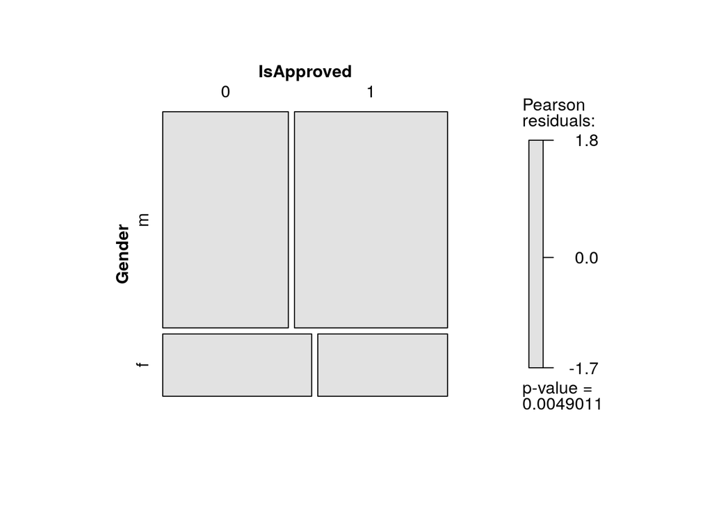

[figure not shown]

There are more women then men applying for Division 1 and the opposite for Division 2. Also, if the project is a continuation it is more likely to be approved. It seems that there is no time effect: proposals are equally likely to be approved in April and October. Apparently proposals from ETH are more likely to be approved, especially than those from UAS/UTE.

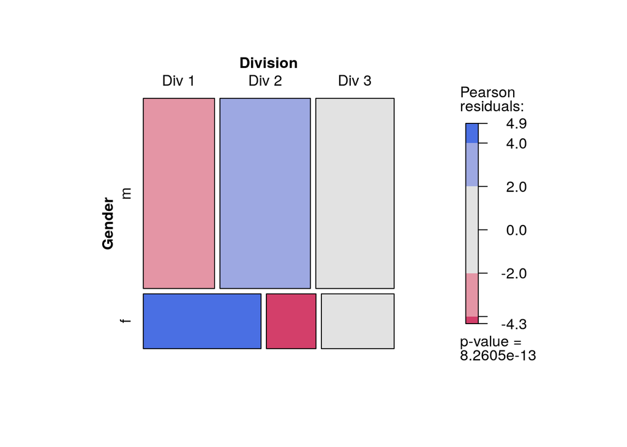

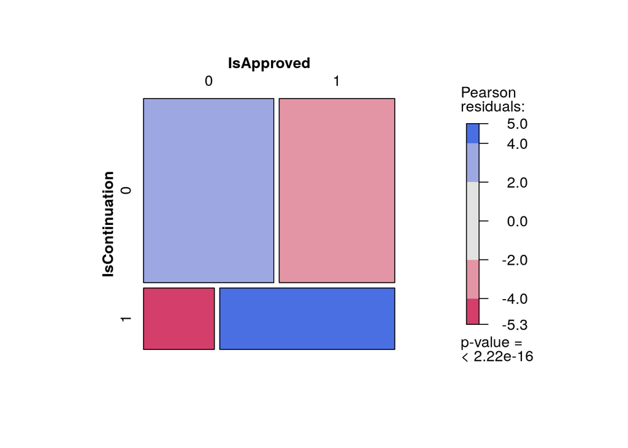

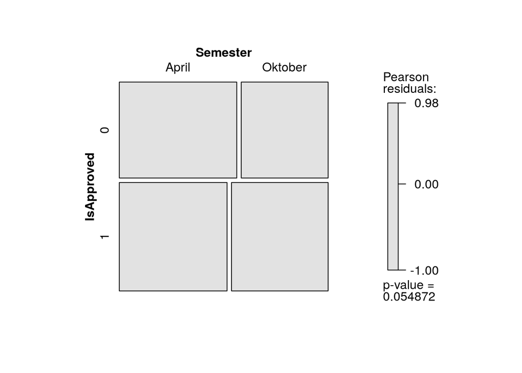

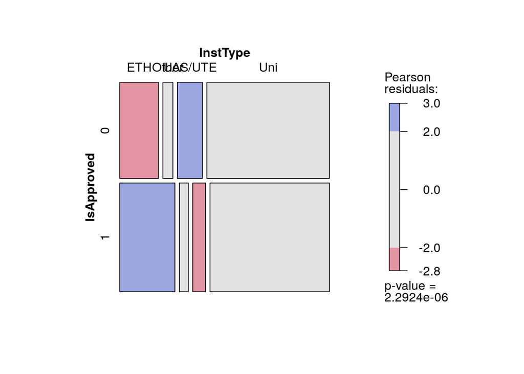

#### How does the Amount requested relates to Amount granted?

On average in Division1 applicants receive almost all the amount of money requested, even if there are lots of outliers. Division 2 is the one with the smallest percentage of money granted.

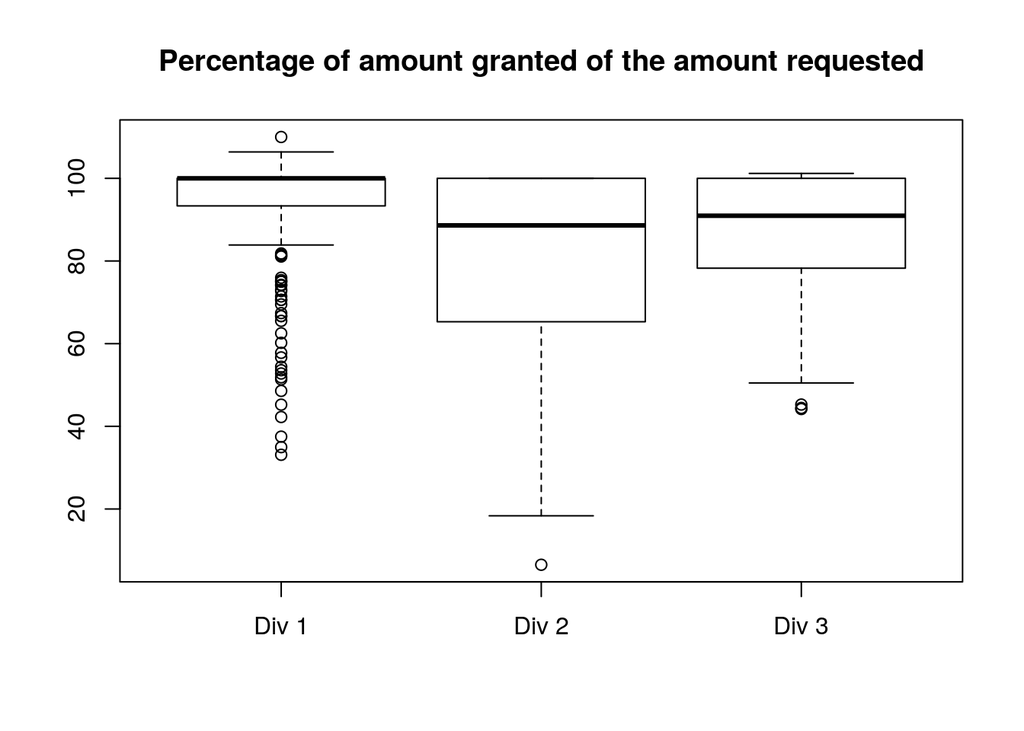

Probably the previous result is due to the fact that in Division1, the AmountRequested, on average, is smaller than in all the other divisions.

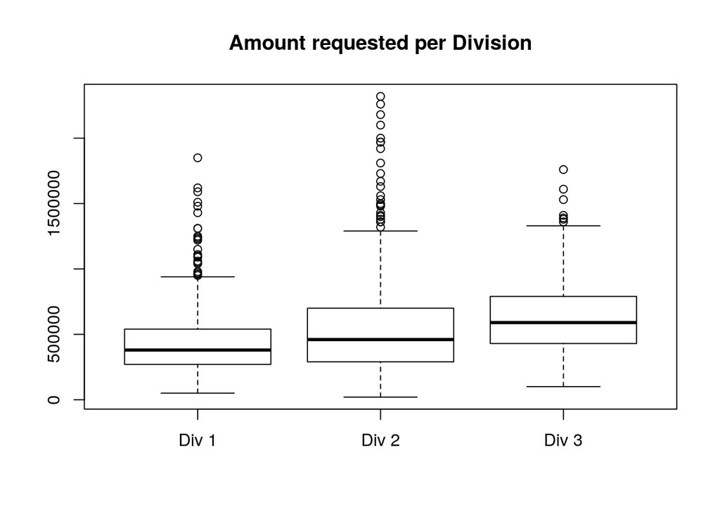

### External Reviewers

#### Is there evidence of gender bias?

#### OverallGrade: Do males or females rate females differently in the OverallGrade? How men and women allocate OverallGrade to all applicants, female applicants, and male applicants

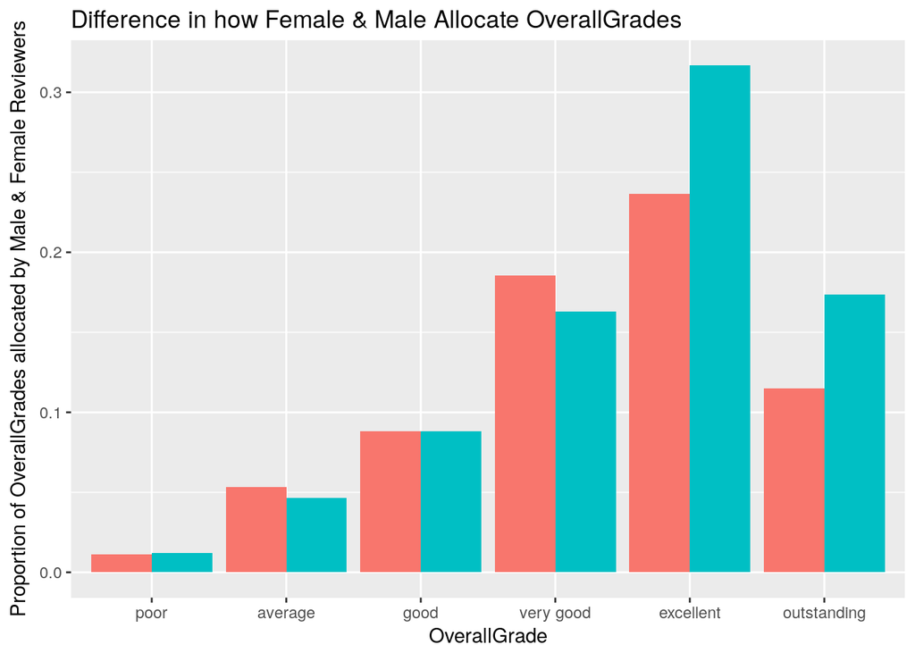

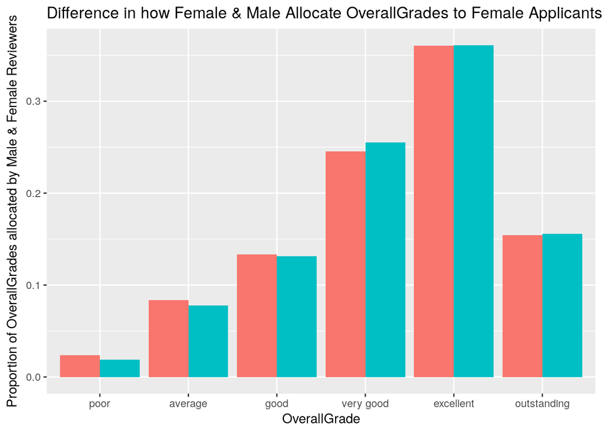

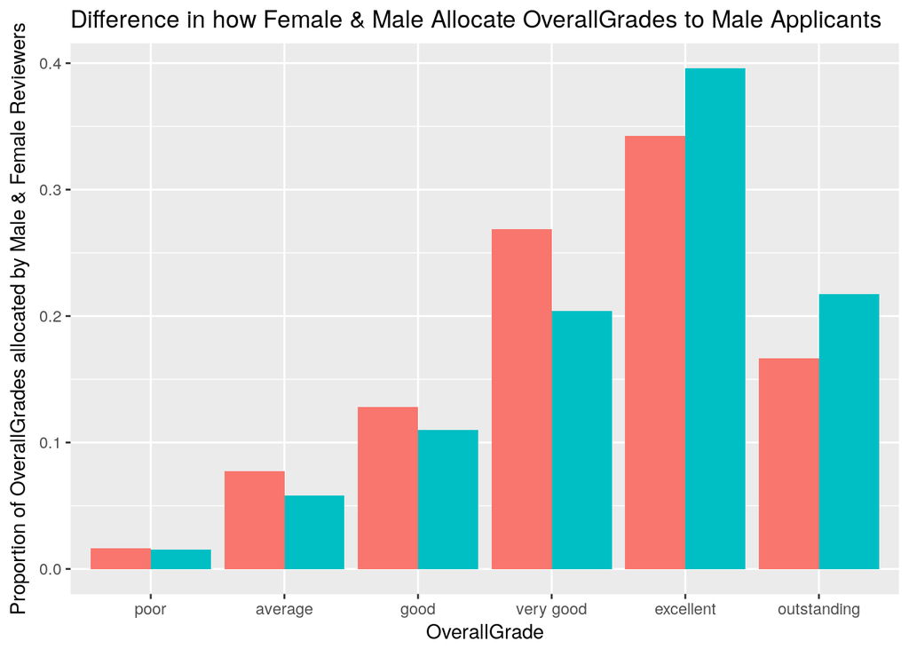

We see male and female reviewers rate female applicants almost identically.

We observe that female reviewers give fewer “Excellent” and “Outstanding” to male applicants, and give more “Very Goods.”

#### ApplicantTrack: Do males or females rate females differently in the ApplicantTrack? How men and women allocate ApplicantTrack to all applicants, female applicants, and male applicants

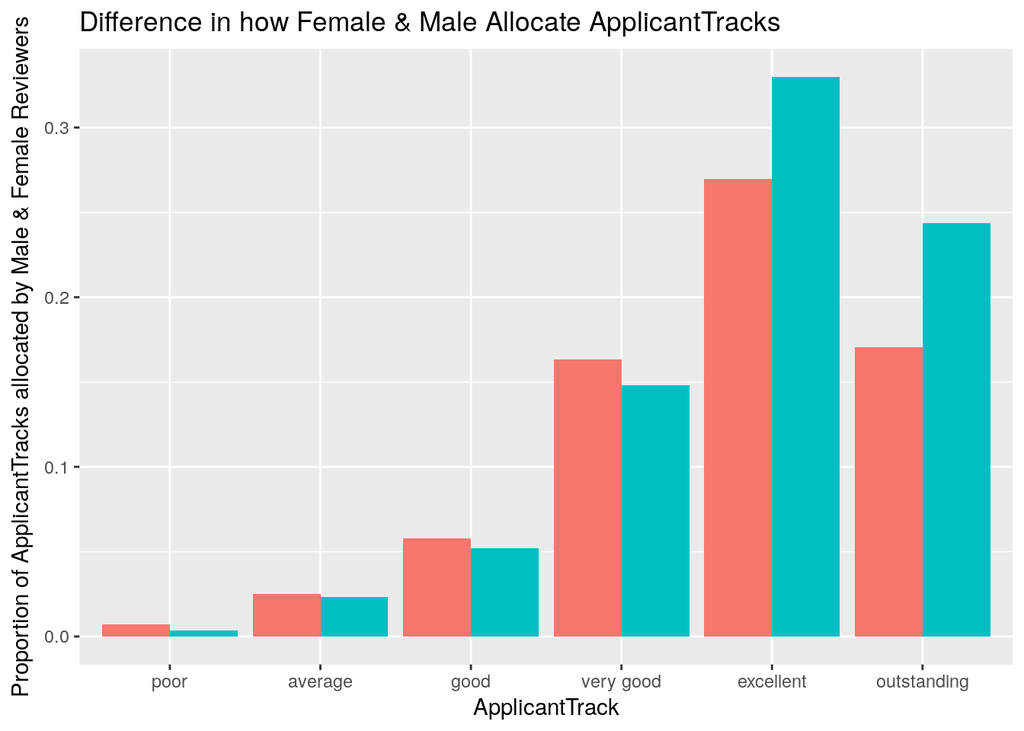

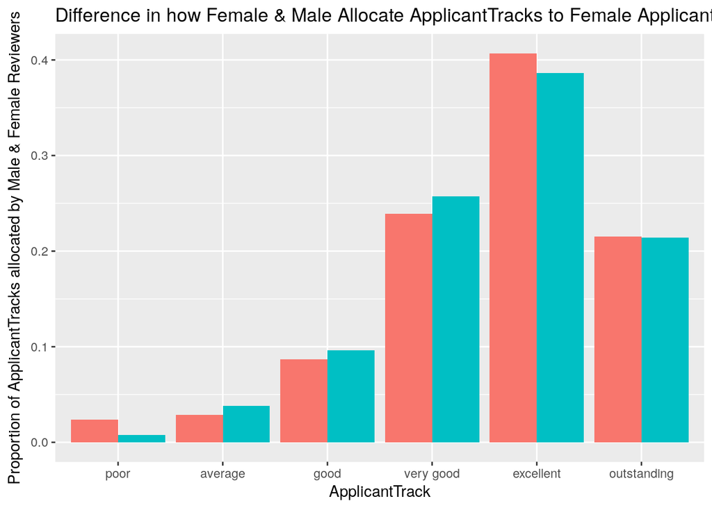

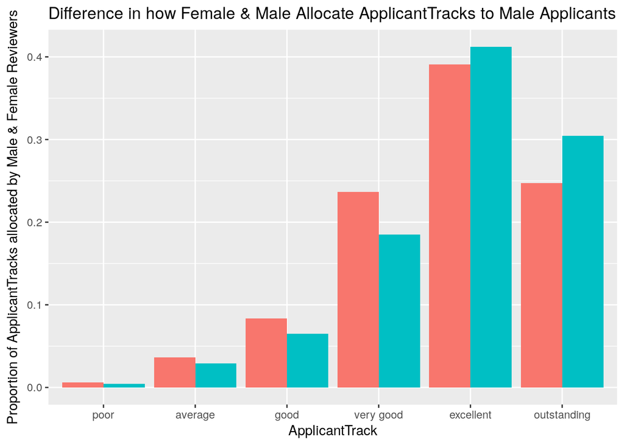

#### ScientificRelevance: Do males or females rate females differently in the ScientificRelevance? How men and women allocate ScientificRelevance to all applicants, female applicants, and male applicants

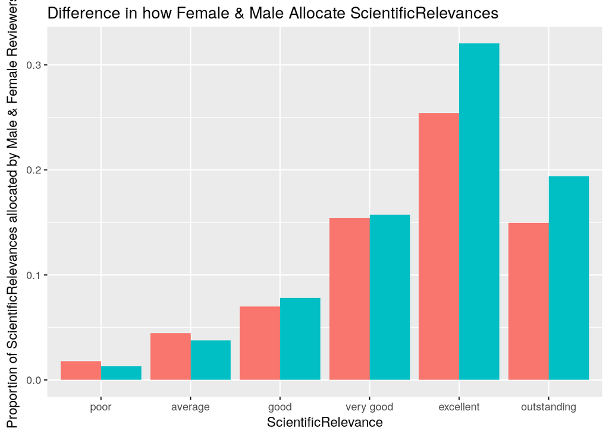

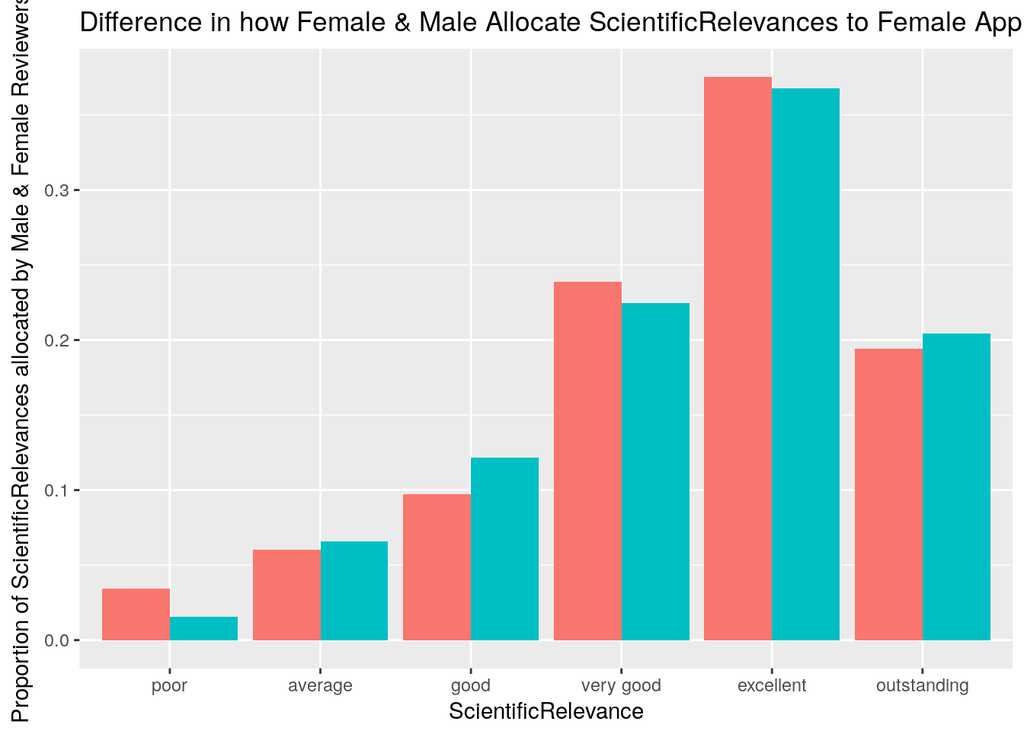

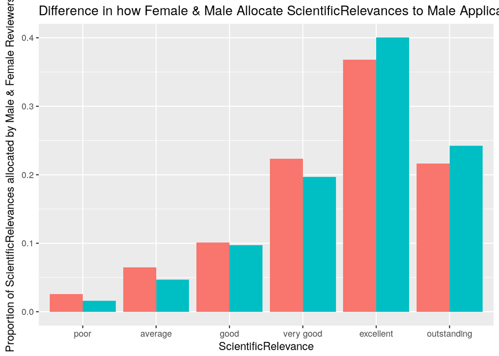

#### Suitability: Do males or females rate females differently in the Suitability? How men and women allocate Suitability to all applicants, female applicants, and male applicants

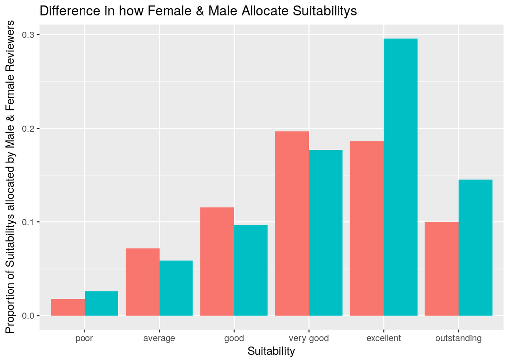

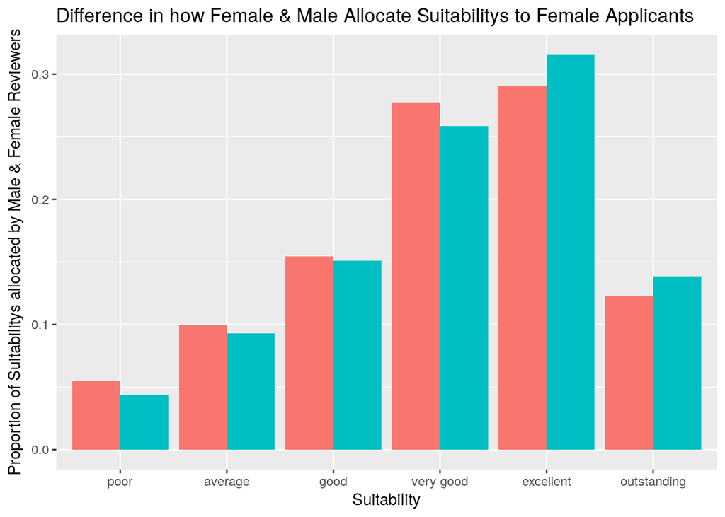

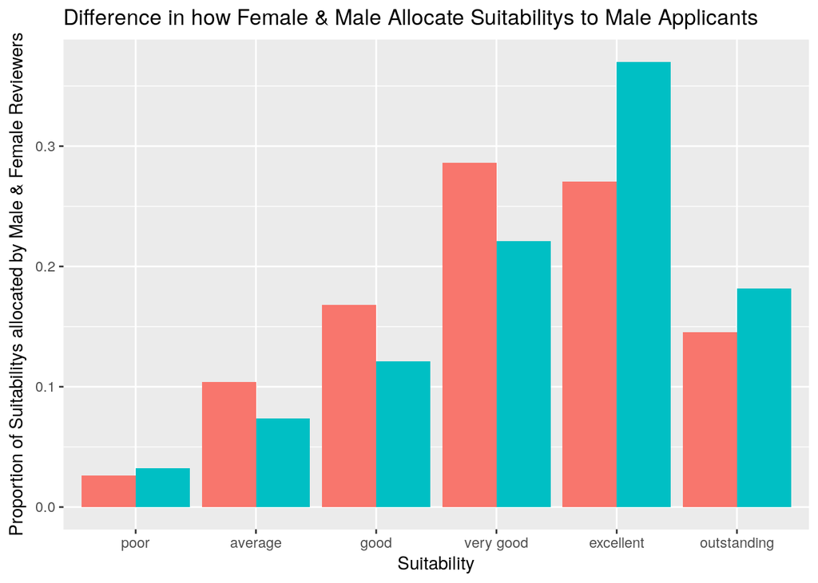

### Internal Reviews

#### ApplicantTrack: Do males or females rate females differently in the ApplicantTrack? How men and women allocate ApplicantTrack to all applicants, female applicants, and male applicants

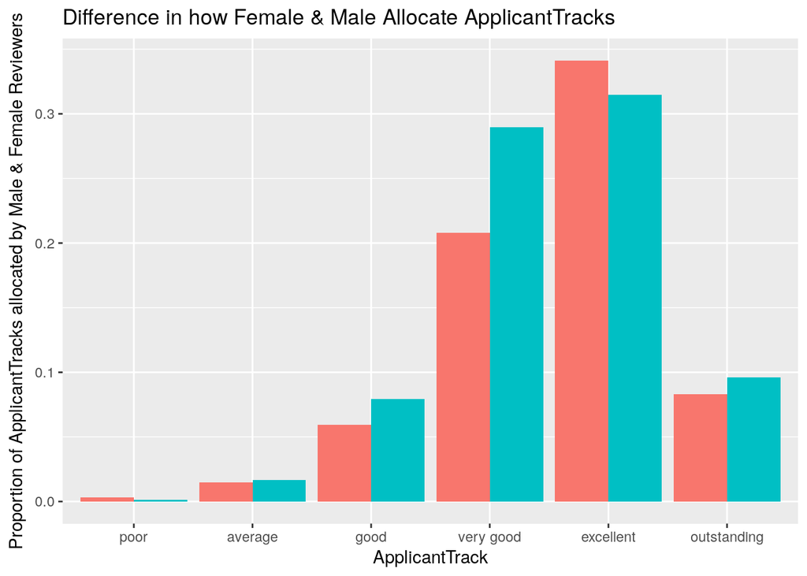

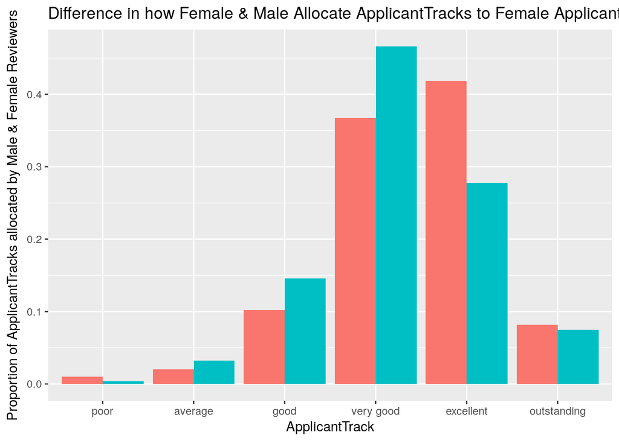

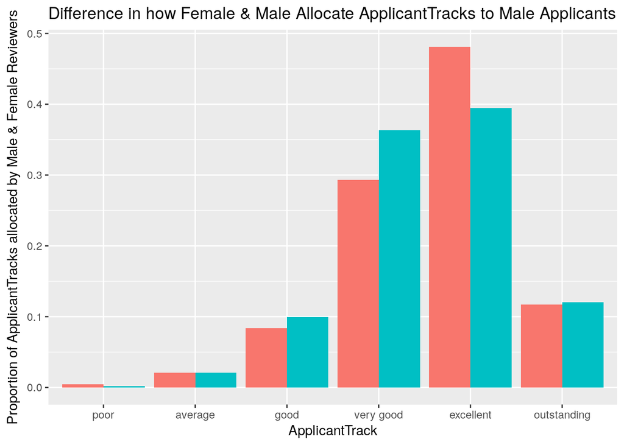